# Time Series Analysis.Test1

A.N.Doynikov,

1/25/2021

# Тест1

## Требования к отчету

Отчет по заданию выполняется в среде RStudio https://rstudio.com/products/rstudio/ На языке программирования R https://www.r-project.org/ и оформляется в виде Rmd файла, который средствами RStudio компилируется в формат , html по желанию слушателя. Задание также может быть выполнено на языке Python и оформлено в виде ноутбука , сохраненного в формате html с пояснениями. Номер варианта соответствует номеру в журнале соответствующей группы. У 11 номера в журнале - 1 вариант, у 12 - второй и так далее.

Срок выполнения задания 1 неделя до следующей лекции.

Задание выполняется на языке R или Python по желанию. Все выводы должны быть строго статистически обоснованы результатами вычислений и соответствующими текстовыми комментариями.

Ошибки исполнения можно исправить только первые 3 дня с момента выдачи задания.

Все замечания и вопросы рассматриваются только письменно в течении 1-ой недели со дня выдачи теста.

Отчет сдавать письменно в виде html файла по e-mail. doynikova$mail.ru.

Результаты выполнения теста будут опубликованы в день следующий лекции. Претензии принимаются по e-mail и будут рассмотрены в течении 1-го дня после публикации результатов.

# Цель теста

В следующих вариантах изучаем пандемию Covid-19. R library(COVID19) содержит оперативные, ежедневно обновляемые данные о развитии пандемии в мире. Иногда внутри данных имеются пропуски, которые следует заполнить, хотя бы среднем арифметическим соседних значений.

Если в Python нет соответствующего пакета такого, как library(COVID19) в R, то получите требуемые данные в R сохраните их в файл, а дальнейшие вычисления сделайте на Python.

Импорт данных осуществляется следующим образом

```r
library(COVID19)
x<-covid19("Russia",level =1,start='2020-04-03')
```

[output not shown]

```r
x <- x[,2:7]
head(x)
```

```
## # A tibble: 6 x 6
##   date       vaccines   tests confirmed recovered deaths
##   <date>        <dbl>   <int>     <int>     <int>  <int>
## 1 2020-04-03       NA  639606      4149       281     34
## 2 2020-04-04       NA  697004      4731       333     43
## 3 2020-04-05       NA  758401      5389       355     45
## 4 2020-04-06       NA  795523      6343       406     47
## 5 2020-04-07       NA  910221      7497       494     58
## 6 2020-04-08       NA 1004719      8672       580     63
```

```r
tail(x)
```

```
## # A tibble: 6 x 6
##   date       vaccines     tests confirmed recovered deaths
##   <date>        <dbl>     <int>     <int>     <int>  <int>
## 1 2021-02-02       NA 102824417   3842145   3304311  72982
## 2 2021-02-03       NA 103207138   3858367   3328696  73497
## 3 2021-02-04       NA 103665675   3874830   3352720  74005
## 4 2021-02-05       NA        NA   3891274   3375999  74520
## 5 2021-02-06       NA        NA   3907653   3398545  75010
## 6 2021-02-07       NA        NA   3923461   3418329  75430
```

Обратите внимание, что в американской нотации сначала идет месяц, а затем число. Итак `2020-04-03` это пятница 3 апреля 2020 года. Данные по пандемии представляют собой накопленные данные по числу вакцинированных,заражений, смертности и выздоровлений и количеству проведенных тестов.

В частности, количество ежедневных заражений можно получить так

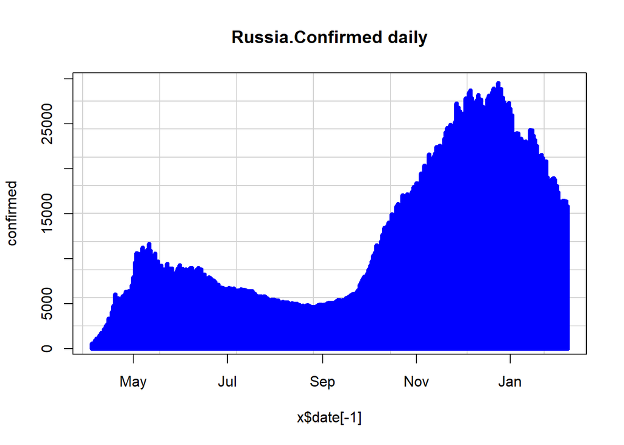

```r
x$date <- as.Date(x$date,"%m/%d/%y")
confirmed <- diff(x$confirmed)
plot(x$date[-1],confirmed,type='h',main = "Russia.Confirmed daily",col = 'blue',lwd = 5,panel.first=grid(nx=NULL,ny = 10,lty=1))
```

А число ежедневных тестов можно получить так

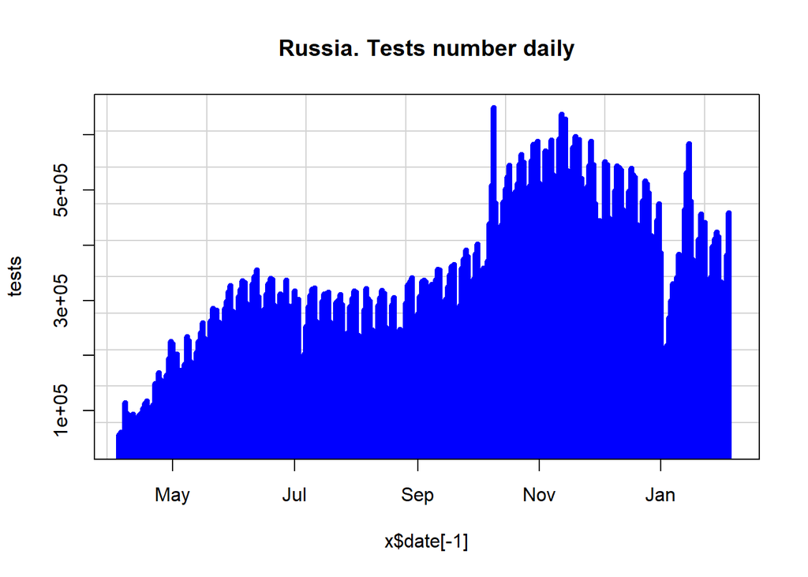

```r
x$date <- as.Date(x$date,"%m/%d/%y")
tests <- diff(x$tests)
plot(x$date[-1],tests,type='h',main = "Russia. Tests number daily",col = 'blue',lwd = 5,panel.first=grid(nx=NULL,ny = 10,lty=1))
```

Оценку сезонного эффекта продемонстрируем по данным смертности от коронавируса в России.

(Skipped Code)

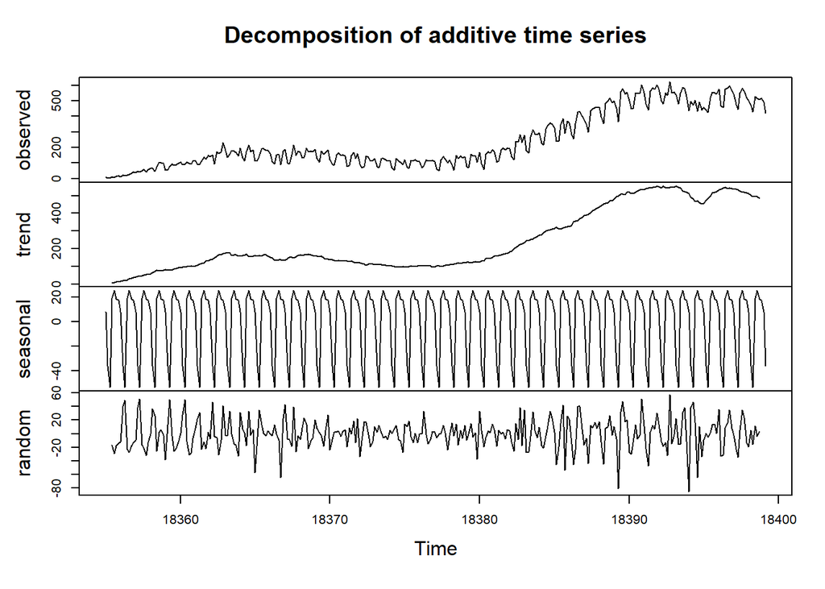

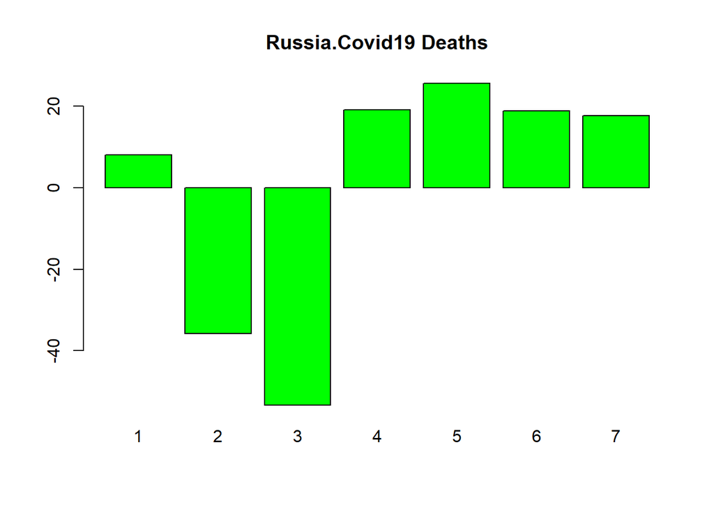

В экономических рядах принято считать геометрическую доходность
$$r_t=S_t/S_{t-1}-1$$
В случае с короновирусом этот процесс будет интерпретироваться как доля (процент если умножить на 100%) каждодневного изменения соответствующей характкристики.

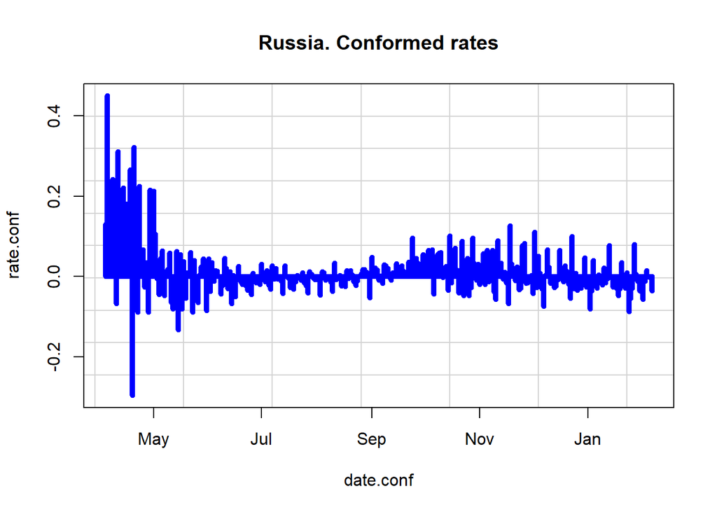

```r
n <-length(confirmed)
x$date <- as.Date(x$date,"%m/%d/%y")
date.conf <- x$date[2:n]
rate.conf <- confirmed[2:n]/confirmed[1:(n-1)]-1
plot(date.conf,rate.conf,type='h',main = "Russia. Conformed rates",col = 'blue',lwd = 5,panel.first=grid(nx=NULL,ny = 10,lty=1))
```

## Вариант 1

- Построить аддитивную и мультипликативную оценку сезонной компоненты числа умерших в каждый день
- Построить графики недельной сезонной компонент с привязкой ко дням недели
- В какой день недели число умерших максимально и минимально?
- Проверить остатки после удаления сезонных компонент на стационарность. Выдать `P-value` соответствующего критерия и вывод о стационарности.

## Вариант 3

- Построить аддитивную и мультипликативную оценку сезонной компоненты для процесса доли (процента) каждодневного изменения числа заболевших. * Построить графики недельной сезонной компонент с привязкой ко дням недели
- В какой день недели изменение доли числа заболевших максимально и минимально?
- Проверить остатки после удаления сезонных компонент на стационарность. Выдать `P-value` соответствующего критерия и вывод о стационарности.

## Вариант 4

- Построить аддитивную и мультипликативную оценку сезонной компоненты для процесса доли (процента) каждодневного изменения числа выздоровлений.
- Построить графики недельной сезонной компонент с привязкой ко дням недели
- В какой день недели изменение доли числа выздоровлений максимально и минимально?
- Проверить остатки после удаления сезонных компонент на стационарность. Выдать `P-value` соответствующего критерия и вывод о стационарности.

## Вариант 5

- Оценить тренд методом простого скольящего среднего с числом точек $M=15$ для числа ежедневных тестов .
- Получить ряд остатков для числа ежедневных тестов. Построить график остатков.
- Построить автокорреляционную функцию для остатков.
- Проверить остатки на стационарность. Выдать `P-value` соответствующего критерия и вывод о стационарности.

## Вариант 6

- Оценить тренд методом простого скольящего среднего с числом точек $M=15$ для числа ежедневных подтвержденных заболеваний.
- Получить ряд остатков для заданного временного ряда.
- Построить график остатков.
- Построить автокорреляционную функцию для остатков.
- Проверить остатки на стационарность. Выдать `P-value` соответствующего критерия и вывод о стационарности.

## Вариант 7

- Оценить тренд методом простого скольящего среднего с числом точек $M=15$ для числа ежедневных умерших от ковида
- Получить ряд остатков для заданного временного ряда ежедневных тестов.
- Построить график остатков.
- Построить автокорреляционную функцию для остатков.
- Проверить остатки на стационарность.Выдать `P-value` соответствующего критерия и вывод о стационарности.

## Вариант 8

Сравниваем первую и вторую волны коронавируса.

- Построить мультипликативную оценку сезонной компоненты для процесса доли (процента) каждодневного изменения числа выздоровлений для данных с 1 апреля по 30 августа 2020 года и с 1 сентября по настоящее время.
- Построить графики недельной сезонной компоненты с привязкой ко дням недели
- В какой день недели изменение доли числа выздоровлений максимально и минимально в период первой и второй волны пандемии?
- Проверить остатки после удаления сезонных компонент на стационарность. Выдать `P-value` соответствующего критерия и вывод о стационарности каждого ряда остатков.

## Вариант 9

Сравниваем первую и вторую волны коронавируса.

- Построить аддитивную оценку сезонной компоненты для процесса ежедневной смертности для данных с 1 апреля по 30 августа 2020 года и с 1 сентября по настоящее время.
- Построить графики недельной сезонной компоненты с привязкой ко дням недели
- В какой день недели смертность максимальна и минимальна в период первой и второй волны пандемии?
- Проверить остатки после удаления сезонных компонент на стационарность. Выдать `P-value` соответствующего критерия и вывод о стационарности каждого ряда остатков.

## Вариант 10

Сравниваем первую и вторую волны коронавируса.

- Построить мультипликативную оценку сезонной компоненты для процесса ежедневных выздоровлений для данных с 1 апреля по 30 августа 2020 года и с 1 сентября по настоящее время.
- Построить графики недельной сезонной компоненты с привязкой ко дням недели
- В какой день недели число выздоровлений максимально и минимально в период первой и второй волны пандемии?
- Проверить остатки после удаления сезонных компонент на стационарность. Выдать `P-value` соответствующего критерия и вывод о стационарности каждого ряда остатков.